# Climatic resources mediate the shape and strength of grassland productivity-richness relationships from local to regional scales - ScienceDirect

## Figures (5)

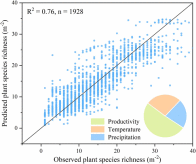

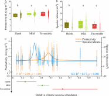

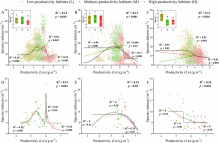

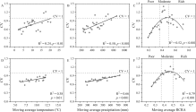

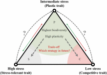

## [Agriculture, Ecosystems & Environment](https://www.sciencedirect.com/journal/agriculture-ecosystems-and-environment)

[Volume 330](https://www.sciencedirect.com/journal/agriculture-ecosystems-and-environment/vol/330/suppl/C), 1 June 2022, 107888

# Climatic resources mediate the shape and strength of grassland productivity-richness relationships from local to regional scales

[JianqingDu<sup>a</sup><sup>b</sup>](https://www.sciencedirect.com/science/article/abs/pii/S0167880922000378#!)[YanfenWang<sup>a</sup><sup>b</sup><sup>c</sup>](https://www.sciencedirect.com/science/article/abs/pii/S0167880922000378#!)[YanbinHao<sup>a</sup><sup>d</sup>](https://www.sciencedirect.com/science/article/abs/pii/S0167880922000378#!)[NicoEisenhauer<sup>e</sup><sup>f</sup>](https://www.sciencedirect.com/science/article/abs/pii/S0167880922000378#!)[YaliLiu<sup>b</sup>](https://www.sciencedirect.com/science/article/abs/pii/S0167880922000378#!)[NanZhang<sup>g</sup>](https://www.sciencedirect.com/science/article/abs/pii/S0167880922000378#!)[KaiXue<sup>a</sup><sup>b</sup>](https://www.sciencedirect.com/science/article/abs/pii/S0167880922000378#!)[XiaoyongCui<sup>a</sup><sup>d</sup>](https://www.sciencedirect.com/science/article/abs/pii/S0167880922000378#!)[XingliangXu<sup>h</sup>](https://www.sciencedirect.com/science/article/abs/pii/S0167880922000378#!)[Richard D.Bardgett<sup>i</sup>](https://www.sciencedirect.com/science/article/abs/pii/S0167880922000378#!)[ShipingWang<sup>c</sup><sup>j</sup>](https://www.sciencedirect.com/science/article/abs/pii/S0167880922000378#!)

https://doi.org/10.1016/j.agee.2022.107888[Get rights and content](https://s100.copyright.com/AppDispatchServlet?publisherName=ELS&contentID=S0167880922000378&orderBeanReset=true)

## Highlights

**•**

Climate effects cause inconsistent P-SR relationships from local to regional scales.

**•**

Asynchronous response of P and SR to CR is an abiotic driver of P-SR relationship.

**•**

Unimodal P-SR relationship at regional scale only exists with poor CR.

**•**

None unimodal P-SR relationships at site scale are mostly observed with moderate CR.

**•**

Shape and strength of P-SR relationship strongly vary among sites with moderate CR.

## Abstract

The plant productivity and species richness (P-SR) relationship has been a central topic in ecology for decades. It is increasingly recognized that climate resources (CR, temperature and precipitation) might affect the P-SR relationship as (1) the response of plant productivity and species richness to CR are different; (2) plant-plant interactions change along the CR gradient. However, little is known about how these effects mediate the shape and strength of the P-SR relationship from local-site to regional scales. Here, we proposed a cross-scale framework to disentangle the climatic control over the P-SR relationship in grasslands using the HerbDivNet dataset, which covers 28 natural grasslands in 19 countries and 6 continents with wide precipitation and temperature gradients. Our results showed that, at the local-site scale, a humped-back P-SR relationship is common at sites under poor and rich CR conditions, whereas both the shape and strength of the P-SR relationship strongly vary among sites under moderate CR condition. However, at the regional scale, the humped-back P-SR relationship is only observed under poor CR condition. We suggested that the asynchronous responses of productivity and species richness to increasing CR is an abiotic driver of the inconsistent P-SR relationships along the climatic gradient in addition to the changing plant-plant interactions suggested by the stress-gradient hypothesis. These findings help to reconcile the long-standing debate over the P-SR relationship and highlight the importance of CR conditions in developing or comparing [grassland ecosystem](https://www.sciencedirect.com/topics/earth-and-planetary-sciences/grassland-ecosystem) theories and management at small scales.

## Keywords

Productivity

Species richness

Productivity-richness relationship

Climatic resource

Plant strategies

Grassland

## Data and code availability statement

The raw data used in this study is from the Herbaceous Diversity Network (HerbDivNet), which is archived in Dryad (https://datadryad.org/stash/dataset/doi:10.5061/dryad.038q8). Other supplementary data that support the findings of this study and the code for the machine learning model can be found in the supporting files accompanying the paper.